# Problem 5: Clustering Palmer Penguins

This notebook implements every part of Problem 5 from HW3 using `penguins.csv`. The clustering code below implements Lloyd's k-means algorithm from scratch, and scikit-learn is only used for the silhouette score requested in part (f).

```python
import numpy as np
import pandas as pd
import matplotlib.pyplot as plt
import seaborn as sns
from sklearn.metrics import silhouette_score

sns.set_theme(style="whitegrid", context="notebook")
plt.rcParams["figure.figsize"] = (7, 5)
plt.rcParams["axes.spines.top"] = False
plt.rcParams["axes.spines.right"] = False

FEATURES = ["bill_length_mm", "bill_depth_mm", "flipper_length_mm", "body_mass_g"]
df = pd.read_csv("penguins.csv")
```

## (a) Exploratory Data Analysis

### (a)(i) Basics

```python
print("Shape:", df.shape)
display(df.describe())

print("Penguins per species:")
display(df["species"].value_counts().rename("count").to_frame())

print("Penguins per island:")
display(df["island"].value_counts().rename("count").to_frame())
```

```
Shape: (344, 8)
```

|  | bill_length_mm | bill_depth_mm | flipper_length_mm | body_mass_g | year |
| --- | --- | --- | --- | --- | --- |
| count | 342.000000 | 342.000000 | 342.000000 | 342.000000 | 344.000000 |
| mean | 43.921930 | 17.151170 | 200.915205 | 4201.754386 | 2008.029070 |
| std | 5.459584 | 1.974793 | 14.061714 | 801.954536 | 0.818356 |
| min | 32.100000 | 13.100000 | 172.000000 | 2700.000000 | 2007.000000 |
| 25% | 39.225000 | 15.600000 | 190.000000 | 3550.000000 | 2007.000000 |
| 50% | 44.450000 | 17.300000 | 197.000000 | 4050.000000 | 2008.000000 |
| 75% | 48.500000 | 18.700000 | 213.000000 | 4750.000000 | 2009.000000 |
| max | 59.600000 | 21.500000 | 231.000000 | 6300.000000 | 2009.000000 |

```
Penguins per species:
```

| species | count |
| --- | --- |
| Adelie | 152 |
| Gentoo | 124 |
| Chinstrap | 68 |

```
Penguins per island:
```

| island | count |
| --- | --- |
| Biscoe | 168 |
| Dream | 124 |
| Torgersen | 52 |

### (a)(ii) Missing values

The assignment asks us to drop rows with any missing value in the four numerical morphological features.

```python
missing_by_column = df.isna().sum().rename("missing_values").to_frame()
display(missing_by_column)

penguins = df.dropna(subset=FEATURES).copy().reset_index(drop=True)
print(f"Rows remaining after dropping NaN values in {FEATURES}: {len(penguins)}")
```

|  | missing_values |
| --- | --- |
| species | 0 |
| island | 0 |
| bill_length_mm | 2 |
| bill_depth_mm | 2 |
| flipper_length_mm | 2 |
| body_mass_g | 2 |
| sex | 11 |
| year | 0 |

```
Rows remaining after dropping NaN values in ['bill_length_mm', 'bill_depth_mm', 'flipper_length_mm', 'body_mass_g']: 342
```

### (a)(iii) Visible clusters

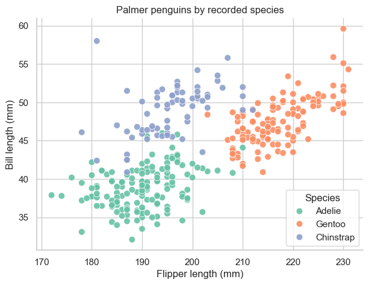

```python
fig, ax = plt.subplots(figsize=(7, 5))
sns.scatterplot(
    data=penguins,
    x="flipper_length_mm",
    y="bill_length_mm",
    hue="species",
    palette="Set2",
    s=60,
    alpha=0.9,
    ax=ax,
)
ax.set_title("Palmer penguins by recorded species")
ax.set_xlabel("Flipper length (mm)")
ax.set_ylabel("Bill length (mm)")
ax.legend(title="Species")
plt.show()
```

There are visible groups, but not three perfectly separated blobs in this projection. Gentoo is the easiest to separate because it tends to have much longer flippers, while Adelie and Chinstrap overlap more in the flipper-length / bill-length view.

## (b) Preprocessing

### (b)(i) Pick the features

```python
X_raw = penguins[FEATURES].to_numpy(dtype=float)
species = penguins["species"].copy()

print("Feature matrix shape:", X_raw.shape)
display(penguins[FEATURES].head())
```

```
Feature matrix shape: (342, 4)
```

|  | bill_length_mm | bill_depth_mm | flipper_length_mm | body_mass_g |
| --- | --- | --- | --- | --- |
| 0 | 39.1 | 18.7 | 181.0 | 3750.0 |
| 1 | 39.5 | 17.4 | 186.0 | 3800.0 |
| 2 | 40.3 | 18.0 | 195.0 | 3250.0 |
| 3 | 36.7 | 19.3 | 193.0 | 3450.0 |
| 4 | 39.3 | 20.6 | 190.0 | 3650.0 |

### (b)(ii) Why standardize

k-means uses Euclidean distance, so features measured on larger numerical scales dominate the objective. Here, body mass is measured in thousands of grams while bill measurements are in millimeters, so without standardization the clustering would mostly optimize body mass and underweight bill and flipper geometry.

### (b)(iii) Standardize

```python
feature_means = X_raw.mean(axis=0)
feature_stds = X_raw.std(axis=0, ddof=0)
X = (X_raw - feature_means) / feature_stds

standardized_summary = pd.DataFrame(
    {
        "mean_after_standardization": X.mean(axis=0),
        "std_after_standardization": X.std(axis=0, ddof=0),
    },
    index=FEATURES,
)
display(standardized_summary)
```

|  | mean_after_standardization | std_after_standardization |
| --- | --- | --- |
| bill_length_mm | 1.662088e-16 | 1.0 |
| bill_depth_mm | 4.155221e-16 | 1.0 |
| flipper_length_mm | -8.310441e-16 | 1.0 |
| body_mass_g | 8.310441e-17 | 1.0 |

## (c) Implement k-means from scratch

```python
def kmeans(X, k, max_iter=100, seed=0):
    # returns (centroids, labels, inertia)
    X = np.asarray(X, dtype=float)
    n_samples = X.shape[0]
    if not 1 <= k <= n_samples:
        raise ValueError("k must be between 1 and the number of rows in X")

    rng = np.random.default_rng(seed)
    initial_indices = rng.choice(n_samples, size=k, replace=False)
    centroids = X[initial_indices].copy()

    labels = None
    inertia_history = []

    for _ in range(max_iter):
        squared_distances = ((X[:, None, :] - centroids[None, :, :]) ** 2).sum(axis=2)
        new_labels = squared_distances.argmin(axis=1)

        new_centroids = centroids.copy()
        for cluster_id in range(k):
            cluster_mask = new_labels == cluster_id
            if cluster_mask.any():
                new_centroids[cluster_id] = X[cluster_mask].mean(axis=0)

        inertia = float(((X - new_centroids[new_labels]) ** 2).sum())
        inertia_history.append(inertia)

        if labels is not None and np.array_equal(new_labels, labels):
            labels = new_labels
            centroids = new_centroids
            break

        labels = new_labels
        centroids = new_centroids

    kmeans.inertia_history_ = inertia_history
    return centroids, labels, inertia_history[-1]


def best_kmeans(X, k, seeds=range(10), max_iter=100):
    best = None
    for seed in seeds:
        centroids, labels, inertia = kmeans(X, k, max_iter=max_iter, seed=seed)
        result = {
            "seed": seed,
            "centroids": centroids,
            "labels": labels,
            "inertia": inertia,
            "history": kmeans.inertia_history_.copy(),
        }
        if best is None or inertia < best["inertia"]:
            best = result
    return best
```

### (c)(ii) Sanity check on the objective

```
Final inertia for seed 0: 486.202
Inertia history: [555.582 488.346 487.246 486.369 486.268 486.202 486.202]
Monotone non-increasing: True
```

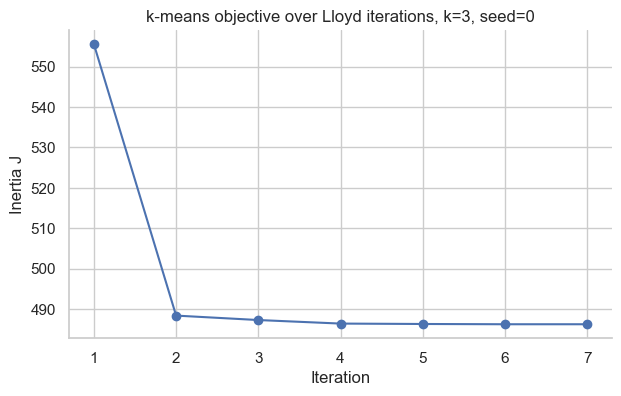

```python
_, _, example_inertia = kmeans(X, k=3, seed=0)
history = np.array(kmeans.inertia_history_)

print(f"Final inertia for seed 0: {example_inertia:.3f}")
print("Inertia history:", np.round(history, 3))
print("Monotone non-increasing:", bool(np.all(np.diff(history) <= 1e-10)))

fig, ax = plt.subplots(figsize=(7, 4))
ax.plot(np.arange(1, len(history) + 1), history, marker="o")
ax.set_title("k-means objective over Lloyd iterations, k=3, seed=0")
ax.set_xlabel("Iteration")
ax.set_ylabel("Inertia J")
plt.show()
```

The objective is monotone non-increasing on this run, as expected for Lloyd's algorithm.

## (d) Cluster and validate

Because k-means can get stuck in a poor local minimum, the main `k=3` clustering below uses the best inertia among seeds 0 through 9. Part (g) studies that initialization sensitivity directly.

```python
main_run = best_kmeans(X, k=3, seeds=range(10))
centroids = main_run["centroids"]
cluster_labels = main_run["labels"]
final_inertia = main_run["inertia"]

print(f"Best seed among 0..9: {main_run['seed']}")
print(f"Final inertia for k=3: {final_inertia:.3f}")
```

```
Best seed among 0..9: 2
Final inertia for k=3: 379.393
```

### (d)(ii) Did we rediscover the species?

```python
cluster_species_table = pd.crosstab(
    pd.Series(cluster_labels, name="cluster"),
    species.rename("species"),
)
purity = cluster_species_table.max(axis=1).sum() / cluster_species_table.to_numpy().sum()

display(cluster_species_table)
print(f"Clustering purity: {purity:.3f}")
```

| species cluster | Adelie | Chinstrap | Gentoo |
| --- | --- | --- | --- |
| 0 | 24 | 63 | 0 |
| 1 | 127 | 5 | 0 |
| 2 | 0 | 0 | 123 |

```
Clustering purity: 0.915
```

The clustering strongly recovers Gentoo, and it partially separates Adelie from Chinstrap. The main confusion is between Adelie and Chinstrap, which matches the species-colored scatter plot from part (a).

### (d)(iii) Cluster profiles in original units

```python
centroids_original_units = centroids * feature_stds + feature_means
centroid_table = pd.DataFrame(centroids_original_units, columns=FEATURES)
centroid_table.index.name = "cluster"
display(centroid_table.round(2))
```

| cluster | bill_length_mm | bill_depth_mm | flipper_length_mm | body_mass_g |
| --- | --- | --- | --- | --- |
| 0 | 47.53 | 18.76 | 196.90 | 3902.01 |
| 1 | 38.21 | 18.11 | 188.40 | 3584.66 |
| 2 | 47.50 | 14.98 | 217.19 | 5076.02 |

Cluster 0 represents penguins with relatively long bills, deep bills, medium flippers, and medium body mass; this profile is closest to Chinstrap.

Cluster 1 represents smaller penguins with shorter bills, deep bills, shorter flippers, and lower body mass; this profile is closest to Adelie.

Cluster 2 represents larger penguins with long flippers, high body mass, and shallower bills; this profile is closest to Gentoo.

### (d)(iv) Visualize clusters

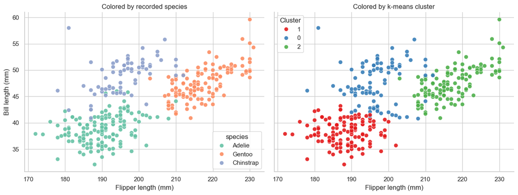

```python
plot_df = penguins.copy()
plot_df["cluster"] = cluster_labels.astype(str)

fig, axes = plt.subplots(1, 2, figsize=(13, 5), sharex=True, sharey=True)
sns.scatterplot(
    data=plot_df,
    x="flipper_length_mm",
    y="bill_length_mm",
    hue="species",
    palette="Set2",
    s=55,
    alpha=0.9,
    ax=axes[0],
)
axes[0].set_title("Colored by recorded species")
axes[0].set_xlabel("Flipper length (mm)")
axes[0].set_ylabel("Bill length (mm)")

sns.scatterplot(
    data=plot_df,
    x="flipper_length_mm",
    y="bill_length_mm",
    hue="cluster",
    palette="Set1",
    s=55,
    alpha=0.9,
    ax=axes[1],
)
axes[1].set_title("Colored by k-means cluster")
axes[1].set_xlabel("Flipper length (mm)")
axes[1].set_ylabel("Bill length (mm)")
axes[1].legend(title="Cluster")
plt.tight_layout()
plt.show()
```

The cluster-colored plot looks similar to the species-colored plot for Gentoo, but differs in the Adelie/Chinstrap overlap region. k-means makes a geometric split there, while the species labels are not perfectly separated in this two-dimensional projection.

## (e) The elbow method

|  | k | mean_inertia | std_inertia | min_inertia |
| --- | --- | --- | --- | --- |
| 0 | 1 | 1368.000 | 0.000 | 1368.000 |
| 1 | 2 | 565.708 | 0.000 | 565.708 |
| 2 | 3 | 411.627 | 48.865 | 379.393 |
| 3 | 4 | 305.269 | 5.222 | 300.400 |
| 4 | 5 | 259.483 | 27.127 | 232.597 |
| 5 | 6 | 244.537 | 30.338 | 205.127 |
| 6 | 7 | 209.003 | 30.523 | 187.155 |
| 7 | 8 | 185.960 | 22.712 | 171.368 |
| 8 | 9 | 179.548 | 23.879 | 160.739 |
| 9 | 10 | 162.613 | 9.241 | 152.667 |

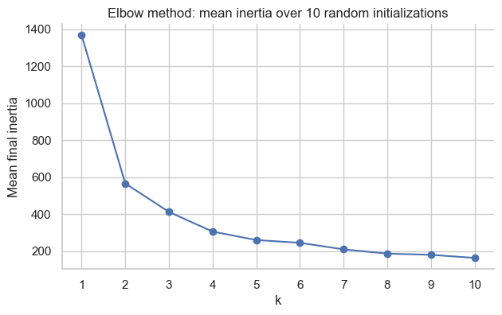

```python
elbow_rows = []
for k in range(1, 11):
    inertias = [kmeans(X, k=k, seed=seed)[2] for seed in range(10)]
    elbow_rows.append(
        {
            "k": k,
            "mean_inertia": np.mean(inertias),
            "std_inertia": np.std(inertias, ddof=0),
            "min_inertia": np.min(inertias),
        }
    )

elbow_df = pd.DataFrame(elbow_rows)
display(elbow_df.round(3))

fig, ax = plt.subplots(figsize=(7, 4))
ax.plot(elbow_df["k"], elbow_df["mean_inertia"], marker="o")
ax.set_xticks(range(1, 11))
ax.set_title("Elbow method: mean inertia over 10 random initializations")
ax.set_xlabel("k")
ax.set_ylabel("Mean final inertia")
plt.show()
```

The clearest bend is at `k = 2`: moving from one cluster to two gives a very large drop, and later improvements are more gradual. There is still a smaller improvement at `k = 3`, which is biologically meaningful because the dataset has three recorded species, but the elbow alone says the strongest morphological split is closer to two groups.

## (f) Silhouette score

|  | k | best_seed | best_inertia | silhouette |
| --- | --- | --- | --- | --- |
| 0 | 2 | 0 | 565.708 | 0.532 |
| 1 | 3 | 2 | 379.393 | 0.447 |
| 2 | 4 | 1 | 300.400 | 0.400 |
| 3 | 5 | 6 | 232.597 | 0.378 |
| 4 | 6 | 4 | 205.127 | 0.369 |
| 5 | 7 | 6 | 187.155 | 0.334 |
| 6 | 8 | 9 | 171.368 | 0.297 |
| 7 | 9 | 4 | 160.739 | 0.282 |
| 8 | 10 | 1 | 152.667 | 0.274 |

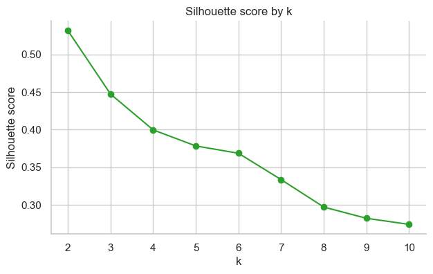

```
Best silhouette occurs at k=2 with score 0.532.
```

```python
silhouette_rows = []
for k in range(2, 11):
    run = best_kmeans(X, k=k, seeds=range(10))
    score = silhouette_score(X, run["labels"])
    silhouette_rows.append(
        {
            "k": k,
            "best_seed": run["seed"],
            "best_inertia": run["inertia"],
            "silhouette": score,
        }
    )

silhouette_df = pd.DataFrame(silhouette_rows)
display(silhouette_df.round(3))

fig, ax = plt.subplots(figsize=(7, 4))
ax.plot(silhouette_df["k"], silhouette_df["silhouette"], marker="o", color="tab:green")
ax.set_xticks(range(2, 11))
ax.set_title("Silhouette score by k")
ax.set_xlabel("k")
ax.set_ylabel("Silhouette score")
plt.show()

best_silhouette_row = silhouette_df.loc[silhouette_df["silhouette"].idxmax()]
print(
    f"Best silhouette occurs at k={int(best_silhouette_row['k'])} "
    f"with score {best_silhouette_row['silhouette']:.3f}."
)
```

The silhouette score also prefers `k = 2`, so it agrees with the strongest elbow signal. I would trust that for the unsupervised geometry of these four standardized features: the strongest split is Gentoo versus non-Gentoo, while Adelie and Chinstrap are less cleanly separated by k-means.

## (g) Sensitivity to initialization

|  | seed | inertia |
| --- | --- | --- |
| count | 50.000 | 50.000 |
| mean | 24.500 | 407.466 |
| std | 14.577 | 47.193 |
| min | 0.000 | 379.393 |
| 25% | 12.250 | 379.393 |
| 50% | 24.500 | 379.403 |
| 75% | 36.750 | 459.985 |
| max | 49.000 | 486.297 |

```
Lowest-inertia seed: 2 with inertia 379.393
Highest-inertia seed: 1 with inertia 486.297
Spread: 106.905
```

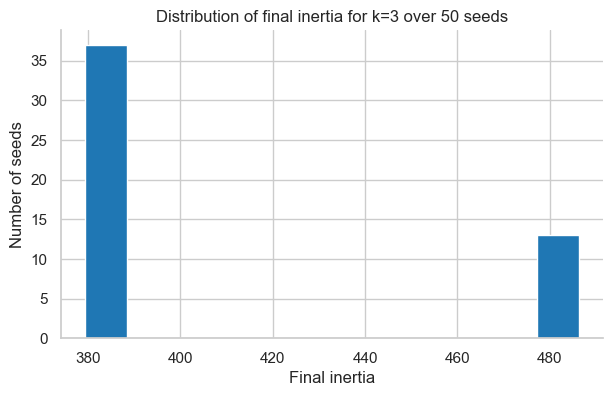

```python
seed_rows = []
for seed in range(50):
    centroids_seed, labels_seed, inertia_seed = kmeans(X, k=3, seed=seed)
    seed_rows.append({"seed": seed, "inertia": inertia_seed, "labels": labels_seed})

seed_df = pd.DataFrame(seed_rows)
display(seed_df[["seed", "inertia"]].describe().round(3))

best_seed = int(seed_df.loc[seed_df["inertia"].idxmin(), "seed"])
worst_seed = int(seed_df.loc[seed_df["inertia"].idxmax(), "seed"])
best_seed_inertia = float(seed_df.loc[seed_df["inertia"].idxmin(), "inertia"])
worst_seed_inertia = float(seed_df.loc[seed_df["inertia"].idxmax(), "inertia"])

print(f"Lowest-inertia seed: {best_seed} with inertia {best_seed_inertia:.3f}")
print(f"Highest-inertia seed: {worst_seed} with inertia {worst_seed_inertia:.3f}")
print(f"Spread: {worst_seed_inertia - best_seed_inertia:.3f}")

fig, ax = plt.subplots(figsize=(7, 4))
ax.hist(seed_df["inertia"], bins=12, color="tab:blue", edgecolor="white")
ax.set_title("Distribution of final inertia for k=3 over 50 seeds")
ax.set_xlabel("Final inertia")
ax.set_ylabel("Number of seeds")
plt.show()
```

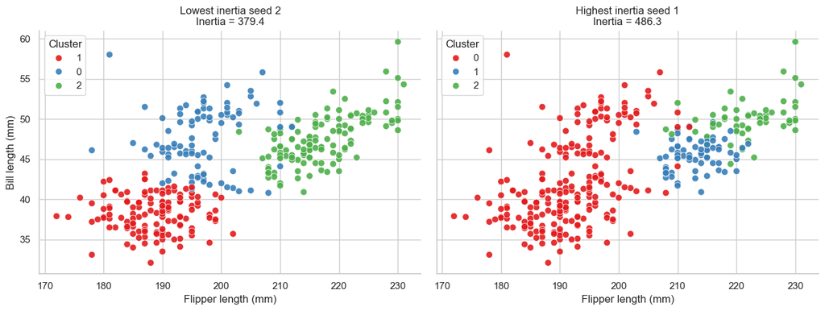

```python
fig, axes = plt.subplots(1, 2, figsize=(13, 5), sharex=True, sharey=True)
for ax, seed, title in [
    (axes[0], best_seed, f"Lowest inertia seed {best_seed}"),
    (axes[1], worst_seed, f"Highest inertia seed {worst_seed}"),
]:
    _, labels_seed, inertia_seed = kmeans(X, k=3, seed=seed)
    temp = penguins.copy()
    temp["cluster"] = labels_seed.astype(str)
    sns.scatterplot(
        data=temp,
        x="flipper_length_mm",
        y="bill_length_mm",
        hue="cluster",
        palette="Set1",
        s=55,
        alpha=0.9,
        ax=ax,
    )
    ax.set_title(f"{title}\nInertia = {inertia_seed:.1f}")
    ax.set_xlabel("Flipper length (mm)")
    ax.set_ylabel("Bill length (mm)")
    ax.legend(title="Cluster")
plt.tight_layout()
plt.show()
```

The spread is substantial: the worst seed among the first 50 has much higher inertia than the best seed. The two visualizations disagree more than just a few boundary points; the poor run splits Gentoo into two clusters and merges most Adelie and Chinstrap penguins, while the low-inertia run separates Gentoo and gives a more meaningful Adelie/Chinstrap split.

## (h) Summary and recommendation

Using only the four standardized morphological measurements, the strongest unsupervised structure appears to be two groups, not three: both the elbow curve and the silhouette score point most clearly to `k = 2`. A three-cluster solution is still biologically useful because it recovers the recorded species labels with about 91.5% purity when using the best-inertia run among seeds 0 through 9, with Gentoo almost perfectly separated and most remaining confusion between Adelie and Chinstrap. I would report that the data strongly separates Gentoo from the other penguins, while the Adelie/Chinstrap boundary is weaker and more sensitive to initialization. Because Lloyd's algorithm can land in different local minima, any reported k-means result should use multiple random initializations and keep the lowest-inertia run. A limitation is that this analysis uses only four morphological measurements after dropping rows with missing numerical values, so it may miss ecological or genetic information that could distinguish species more reliably.